# Optimal Treatment Analysis

## Outcome Variable

**Outcome Variable:** haz

## Predictor Variables

**Intervention Variable:** perdiar6

**Adjustment Set:**

- arm
- sex
- W_mage
- meducyrs
- W_mhtcm
- W_mwtkg
- W_mbmi
- W_birthwt
- W_birthlen
- W_nrooms
- month
- brthmon
- impfloor
- impsan
- safeh20
- delta_W_mage
- delta_meducyrs
- delta_W_mhtcm
- delta_W_mwtkg
- delta_W_mbmi
- delta_W_birthwt
- delta_W_birthlen
- delta_W_nrooms
- delta_month
- delta_brthmon
- delta_impfloor
- delta_impsan
- delta_safeh20

## Stratifying Variables

The analysis was stratified on these variable(s):

- agecat
- studyid
- country

## Data Summary

| agecat | studyid | country | perdiar6 | n_cell | n |
| --- | --- | --- | --- | --- | --- |
| Birth | ki0047075b-MAL-ED | BANGLADESH | (0%, 5%] | 96 | 257 |
| Birth | ki0047075b-MAL-ED | BANGLADESH | 0% | 86 | 257 |
| Birth | ki0047075b-MAL-ED | BANGLADESH | >5% | 75 | 257 |
| Birth | ki0047075b-MAL-ED | BRAZIL | (0%, 5%] | 13 | 191 |
| Birth | ki0047075b-MAL-ED | BRAZIL | 0% | 176 | 191 |
| Birth | ki0047075b-MAL-ED | BRAZIL | >5% | 2 | 191 |
| Birth | ki0047075b-MAL-ED | INDIA | (0%, 5%] | 109 | 206 |
| Birth | ki0047075b-MAL-ED | INDIA | 0% | 47 | 206 |
| Birth | ki0047075b-MAL-ED | INDIA | >5% | 50 | 206 |
| Birth | ki0047075b-MAL-ED | NEPAL | (0%, 5%] | 57 | 173 |
| Birth | ki0047075b-MAL-ED | NEPAL | 0% | 60 | 173 |
| Birth | ki0047075b-MAL-ED | NEPAL | >5% | 56 | 173 |
| Birth | ki0047075b-MAL-ED | PERU | (0%, 5%] | 88 | 287 |
| Birth | ki0047075b-MAL-ED | PERU | 0% | 83 | 287 |
| Birth | ki0047075b-MAL-ED | PERU | >5% | 116 | 287 |
| Birth | ki0047075b-MAL-ED | SOUTH AFRICA | (0%, 5%] | 50 | 252 |
| Birth | ki0047075b-MAL-ED | SOUTH AFRICA | 0% | 193 | 252 |
| Birth | ki0047075b-MAL-ED | SOUTH AFRICA | >5% | 9 | 252 |
| Birth | ki0047075b-MAL-ED | TANZANIA, UNITED REPUBLIC OF | (0%, 5%] | 42 | 123 |
| Birth | ki0047075b-MAL-ED | TANZANIA, UNITED REPUBLIC OF | 0% | 60 | 123 |
| Birth | ki0047075b-MAL-ED | TANZANIA, UNITED REPUBLIC OF | >5% | 21 | 123 |
| Birth | ki1000109-ResPak | PAKISTAN | (0%, 5%] | 2 | 6 |
| Birth | ki1000109-ResPak | PAKISTAN | 0% | 1 | 6 |
| Birth | ki1000109-ResPak | PAKISTAN | >5% | 3 | 6 |
| Birth | ki1017093-NIH-Birth | BANGLADESH | (0%, 5%] | 3 | 26 |
| Birth | ki1017093-NIH-Birth | BANGLADESH | 0% | 4 | 26 |
| Birth | ki1017093-NIH-Birth | BANGLADESH | >5% | 19 | 26 |
| Birth | ki1017093c-NIH-Crypto | BANGLADESH | (0%, 5%] | 7 | 27 |
| Birth | ki1017093c-NIH-Crypto | BANGLADESH | 0% | 8 | 27 |
| Birth | ki1017093c-NIH-Crypto | BANGLADESH | >5% | 12 | 27 |

[output cut: 102 more lines]

The following strata were considered:

- agecat: 24 months, studyid: ki0047075b-MAL-ED, country: BANGLADESH
- agecat: 24 months, studyid: ki0047075b-MAL-ED, country: BRAZIL
- agecat: 24 months, studyid: ki0047075b-MAL-ED, country: INDIA
- agecat: 24 months, studyid: ki0047075b-MAL-ED, country: NEPAL
- agecat: 24 months, studyid: ki0047075b-MAL-ED, country: PERU
- agecat: 24 months, studyid: ki0047075b-MAL-ED, country: SOUTH AFRICA
- agecat: 24 months, studyid: ki0047075b-MAL-ED, country: TANZANIA, UNITED REPUBLIC OF
- agecat: 24 months, studyid: ki1017093-NIH-Birth, country: BANGLADESH
- agecat: 24 months, studyid: ki1017093b-PROVIDE, country: BANGLADESH
- agecat: 24 months, studyid: ki1017093c-NIH-Crypto, country: BANGLADESH
- agecat: 24 months, studyid: ki1114097-CMIN, country: BANGLADESH
- agecat: 24 months, studyid: ki1114097-CMIN, country: GUINEA-BISSAU
- agecat: 24 months, studyid: ki1114097-CMIN, country: PERU
- agecat: 24 months, studyid: ki1114097-CONTENT, country: PERU
- agecat: 6 months, studyid: ki0047075b-MAL-ED, country: BANGLADESH
- agecat: 6 months, studyid: ki0047075b-MAL-ED, country: BRAZIL
- agecat: 6 months, studyid: ki0047075b-MAL-ED, country: INDIA
- agecat: 6 months, studyid: ki0047075b-MAL-ED, country: NEPAL
- agecat: 6 months, studyid: ki0047075b-MAL-ED, country: PERU
- agecat: 6 months, studyid: ki0047075b-MAL-ED, country: SOUTH AFRICA
- agecat: 6 months, studyid: ki0047075b-MAL-ED, country: TANZANIA, UNITED REPUBLIC OF
- agecat: 6 months, studyid: ki1000109-ResPak, country: PAKISTAN
- agecat: 6 months, studyid: ki1017093-NIH-Birth, country: BANGLADESH
- agecat: 6 months, studyid: ki1017093b-PROVIDE, country: BANGLADESH
- agecat: 6 months, studyid: ki1017093c-NIH-Crypto, country: BANGLADESH
- agecat: 6 months, studyid: ki1114097-CMIN, country: BANGLADESH
- agecat: 6 months, studyid: ki1114097-CMIN, country: BRAZIL
- agecat: 6 months, studyid: ki1114097-CMIN, country: GUINEA-BISSAU
- agecat: 6 months, studyid: ki1114097-CMIN, country: PERU
- agecat: 6 months, studyid: ki1114097-CONTENT, country: PERU
- agecat: Birth, studyid: ki0047075b-MAL-ED, country: BANGLADESH
- agecat: Birth, studyid: ki0047075b-MAL-ED, country: BRAZIL
- agecat: Birth, studyid: ki0047075b-MAL-ED, country: INDIA
- agecat: Birth, studyid: ki0047075b-MAL-ED, country: NEPAL
- agecat: Birth, studyid: ki0047075b-MAL-ED, country: PERU
- agecat: Birth, studyid: ki0047075b-MAL-ED, country: SOUTH AFRICA
- agecat: Birth, studyid: ki0047075b-MAL-ED, country: TANZANIA, UNITED REPUBLIC OF
- agecat: Birth, studyid: ki1000109-ResPak, country: PAKISTAN
- agecat: Birth, studyid: ki1017093-NIH-Birth, country: BANGLADESH
- agecat: Birth, studyid: ki1017093c-NIH-Crypto, country: BANGLADESH
- agecat: Birth, studyid: ki1114097-CMIN, country: BANGLADESH
- agecat: Birth, studyid: ki1114097-CMIN, country: BRAZIL
- agecat: Birth, studyid: ki1114097-CMIN, country: PERU
- agecat: Birth, studyid: ki1114097-CONTENT, country: PERU

### Dropped Strata

Some strata were dropped due to rare outcomes:

- agecat: Birth, studyid: ki0047075b-MAL-ED, country: BRAZIL
- agecat: Birth, studyid: ki1000109-ResPak, country: PAKISTAN
- agecat: Birth, studyid: ki1017093-NIH-Birth, country: BANGLADESH
- agecat: Birth, studyid: ki1114097-CMIN, country: BANGLADESH
- agecat: Birth, studyid: ki1114097-CMIN, country: PERU
- agecat: Birth, studyid: ki1114097-CONTENT, country: PERU
- agecat: 6 months, studyid: ki0047075b-MAL-ED, country: BRAZIL
- agecat: 24 months, studyid: ki0047075b-MAL-ED, country: BRAZIL

## Methods Detail

We’re interested in the causal parameters $E[Y_a]$ for all values of $a \in \mathcal{A}$. These parameters represent the mean outcome if, possibly contrary to fact, we intervened to set all units to have $A=a$. Under the randomization and positivity assumptions, these are identified by the statistical parameters $\psi_a=E_W[E_{Y|A,W}(Y|A=a,W)]$. In addition, we’re interested in the mean of $Y$, $E[Y]$ under no intervention (the observed mean). We will estimate these parameters by using SuperLearner to fit the relevant likelihood factors – $E_{Y|A,W}(Y|A=a,W)$ and $p(A=a|W)$, and then updating our likelihood fit using a joint TMLE.

For unadjusted analyses ($W=\{\}$), initial likelihoods were estimated using Lrnr_glm to estimate the simple $E(Y|A)$ and Lrnr_mean to estimate $p(A)$. For adjusted analyses, a small library containing Lrnr_glmnet, Lrnr_xgboost, and Lrnr_mean was used.

Having estimated these parameters, we will then use the delta method to estimate relative risks and attributable risks relative to a prespecified baseline level of $A$.

# Results Detail

## Results Plots

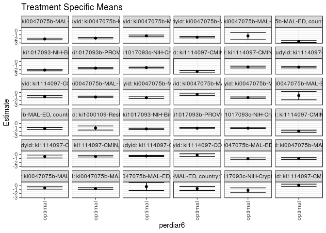

## Results Table

### Parameter: TSM

| agecat | studyid | country | intervention_level | baseline_level | estimate | ci_lower | ci_upper |
| --- | --- | --- | --- | --- | --- | --- | --- |
| Birth | ki0047075b-MAL-ED | BANGLADESH | optimal | observed | -1.0934741 | -1.3133800 | -0.8735683 |
| Birth | ki0047075b-MAL-ED | INDIA | optimal | observed | -1.0258464 | -1.2238904 | -0.8278024 |
| Birth | ki0047075b-MAL-ED | NEPAL | optimal | observed | -0.6709674 | -0.9513997 | -0.3905352 |
| Birth | ki0047075b-MAL-ED | PERU | optimal | observed | -0.8090271 | -0.9878570 | -0.6301973 |
| Birth | ki0047075b-MAL-ED | SOUTH AFRICA | optimal | observed | -0.3381145 | -1.3133378 | 0.6371088 |
| Birth | ki0047075b-MAL-ED | TANZANIA, UNITED REPUBLIC OF | optimal | observed | -0.8125626 | -1.2874747 | -0.3376506 |
| Birth | ki1017093c-NIH-Crypto | BANGLADESH | optimal | observed | -1.2438417 | -1.8277172 | -0.6599663 |
| Birth | ki1114097-CMIN | BRAZIL | optimal | observed | -0.0095594 | -0.2812937 | 0.2621750 |
| 6 months | ki0047075b-MAL-ED | BANGLADESH | optimal | observed | -1.0968876 | -1.2789769 | -0.9147984 |
| 6 months | ki0047075b-MAL-ED | INDIA | optimal | observed | -1.2658765 | -1.4815024 | -1.0502506 |
| 6 months | ki0047075b-MAL-ED | NEPAL | optimal | observed | -0.5193640 | -0.7197170 | -0.3190111 |
| 6 months | ki0047075b-MAL-ED | PERU | optimal | observed | -1.2483326 | -1.4141381 | -1.0825270 |
| 6 months | ki0047075b-MAL-ED | SOUTH AFRICA | optimal | observed | -0.7499755 | -1.7845205 | 0.2845696 |
| 6 months | ki0047075b-MAL-ED | TANZANIA, UNITED REPUBLIC OF | optimal | observed | -1.2521736 | -1.5143727 | -0.9899744 |
| 6 months | ki1000109-ResPak | PAKISTAN | optimal | observed | -1.1201617 | -1.6182017 | -0.6221217 |
| 6 months | ki1017093-NIH-Birth | BANGLADESH | optimal | observed | -1.3393703 | -1.4976307 | -1.1811099 |
| 6 months | ki1017093b-PROVIDE | BANGLADESH | optimal | observed | -1.1491790 | -1.2803362 | -1.0180218 |
| 6 months | ki1017093c-NIH-Crypto | BANGLADESH | optimal | observed | -1.1467267 | -1.2435099 | -1.0499436 |
| 6 months | ki1114097-CMIN | BANGLADESH | optimal | observed | -1.9112650 | -2.1730607 | -1.6494693 |
| 6 months | ki1114097-CMIN | BRAZIL | optimal | observed | -0.5406967 | -0.8942707 | -0.1871227 |
| 6 months | ki1114097-CMIN | GUINEA-BISSAU | optimal | observed | -0.5106401 | -0.6618904 | -0.3593897 |
| 6 months | ki1114097-CMIN | PERU | optimal | observed | -0.4218442 | -0.5650949 | -0.2785936 |
| 6 months | ki1114097-CONTENT | PERU | optimal | observed | -0.1818411 | -0.4861105 | 0.1224283 |
| 24 months | ki0047075b-MAL-ED | BANGLADESH | optimal | observed | -2.0455768 | -2.2540477 | -1.8371059 |
| 24 months | ki0047075b-MAL-ED | INDIA | optimal | observed | -1.8392453 | -2.0349545 | -1.6435362 |
| 24 months | ki0047075b-MAL-ED | NEPAL | optimal | observed | -1.2914119 | -1.5068477 | -1.0759762 |
| 24 months | ki0047075b-MAL-ED | PERU | optimal | observed | -1.6079886 | -1.7853176 | -1.4306596 |
| 24 months | ki0047075b-MAL-ED | SOUTH AFRICA | optimal | observed | -1.2899534 | -2.0879639 | -0.4919430 |
| 24 months | ki0047075b-MAL-ED | TANZANIA, UNITED REPUBLIC OF | optimal | observed | -2.6269095 | -2.8921952 | -2.3616238 |
| 24 months | ki1017093-NIH-Birth | BANGLADESH | optimal | observed | -2.0832282 | -2.2640185 | -1.9024380 |
| 24 months | ki1017093b-PROVIDE | BANGLADESH | optimal | observed | -1.6063805 | -1.7591718 | -1.4535892 |
| 24 months | ki1017093c-NIH-Crypto | BANGLADESH | optimal | observed | -1.4718431 | -1.5824159 | -1.3612703 |
| 24 months | ki1114097-CMIN | BANGLADESH | optimal | observed | -2.3944319 | -2.6041252 | -2.1847386 |
| 24 months | ki1114097-CMIN | GUINEA-BISSAU | optimal | observed | -1.3501728 | -1.5682795 | -1.1320661 |
| 24 months | ki1114097-CMIN | PERU | optimal | observed | -1.3650459 | -1.5450840 | -1.1850079 |
| 24 months | ki1114097-CONTENT | PERU | optimal | observed | -1.0144157 | -1.2903388 | -0.7384926 |

### Parameter: E(Y)

| agecat | studyid | country | intervention_level | baseline_level | estimate | ci_lower | ci_upper |
| --- | --- | --- | --- | --- | --- | --- | --- |
| Birth | ki0047075b-MAL-ED | BANGLADESH | observed | observed | -1.0843969 | -1.2100768 | -0.9587169 |
| Birth | ki0047075b-MAL-ED | INDIA | observed | observed | -1.0106311 | -1.1499962 | -0.8712660 |
| Birth | ki0047075b-MAL-ED | NEPAL | observed | observed | -0.7089017 | -0.8656064 | -0.5521971 |
| Birth | ki0047075b-MAL-ED | PERU | observed | observed | -0.9322300 | -1.0461262 | -0.8183337 |
| Birth | ki0047075b-MAL-ED | SOUTH AFRICA | observed | observed | -0.7068651 | -0.8323249 | -0.5814053 |
| Birth | ki0047075b-MAL-ED | TANZANIA, UNITED REPUBLIC OF | observed | observed | -0.9338211 | -1.1465079 | -0.7211344 |
| Birth | ki1017093c-NIH-Crypto | BANGLADESH | observed | observed | -1.1100000 | -1.5086894 | -0.7113106 |
| Birth | ki1114097-CMIN | BRAZIL | observed | observed | 0.0576522 | -0.1471825 | 0.2624869 |
| 6 months | ki0047075b-MAL-ED | BANGLADESH | observed | observed | -1.2056777 | -1.3231497 | -1.0882058 |
| 6 months | ki0047075b-MAL-ED | INDIA | observed | observed | -1.2203672 | -1.3387619 | -1.1019726 |
| 6 months | ki0047075b-MAL-ED | NEPAL | observed | observed | -0.5610593 | -0.6737915 | -0.4483272 |
| 6 months | ki0047075b-MAL-ED | PERU | observed | observed | -1.3268010 | -1.4351217 | -1.2184802 |
| 6 months | ki0047075b-MAL-ED | SOUTH AFRICA | observed | observed | -1.0633760 | -1.1911088 | -0.9356432 |
| 6 months | ki0047075b-MAL-ED | TANZANIA, UNITED REPUBLIC OF | observed | observed | -1.3601215 | -1.4821830 | -1.2380600 |
| 6 months | ki1000109-ResPak | PAKISTAN | observed | observed | -1.4029220 | -1.6085859 | -1.1972581 |
| 6 months | ki1017093-NIH-Birth | BANGLADESH | observed | observed | -1.4073821 | -1.4960598 | -1.3187043 |
| 6 months | ki1017093b-PROVIDE | BANGLADESH | observed | observed | -1.0871041 | -1.1635539 | -1.0106543 |
| 6 months | ki1017093c-NIH-Crypto | BANGLADESH | observed | observed | -1.1986783 | -1.2700937 | -1.1272630 |
| 6 months | ki1114097-CMIN | BANGLADESH | observed | observed | -1.7844376 | -1.9222926 | -1.6465825 |
| 6 months | ki1114097-CMIN | BRAZIL | observed | observed | -0.6841667 | -0.8870073 | -0.4813261 |
| 6 months | ki1114097-CMIN | GUINEA-BISSAU | observed | observed | -0.6242708 | -0.7083402 | -0.5402014 |
| 6 months | ki1114097-CMIN | PERU | observed | observed | -0.5133753 | -0.5929878 | -0.4337629 |
| 6 months | ki1114097-CONTENT | PERU | observed | observed | -0.3139217 | -0.4868486 | -0.1409948 |
| 24 months | ki0047075b-MAL-ED | BANGLADESH | observed | observed | -1.9431132 | -2.0691678 | -1.8170586 |
| 24 months | ki0047075b-MAL-ED | INDIA | observed | observed | -1.8458150 | -1.9718703 | -1.7197596 |
| 24 months | ki0047075b-MAL-ED | NEPAL | observed | observed | -1.2752193 | -1.3954783 | -1.1549603 |
| 24 months | ki0047075b-MAL-ED | PERU | observed | observed | -1.7500995 | -1.8705474 | -1.6296516 |
| 24 months | ki0047075b-MAL-ED | SOUTH AFRICA | observed | observed | -1.6228361 | -1.7581177 | -1.4875546 |
| 24 months | ki0047075b-MAL-ED | TANZANIA, UNITED REPUBLIC OF | observed | observed | -2.6058879 | -2.7403043 | -2.4714714 |
| 24 months | ki1017093-NIH-Birth | BANGLADESH | observed | observed | -2.1807945 | -2.2835902 | -2.0779987 |
| 24 months | ki1017093b-PROVIDE | BANGLADESH | observed | observed | -1.5861179 | -1.6693668 | -1.5028689 |
| 24 months | ki1017093c-NIH-Crypto | BANGLADESH | observed | observed | -1.4295331 | -1.5127726 | -1.3462935 |
| 24 months | ki1114097-CMIN | BANGLADESH | observed | observed | -2.5109504 | -2.6361514 | -2.3857494 |
| 24 months | ki1114097-CMIN | GUINEA-BISSAU | observed | observed | -1.5769713 | -1.7148941 | -1.4390486 |
| 24 months | ki1114097-CMIN | PERU | observed | observed | -1.4709290 | -1.5934208 | -1.3484372 |
| 24 months | ki1114097-CONTENT | PERU | observed | observed | -0.6962195 | -0.8674103 | -0.5250287 |

### Parameter: PAR

| agecat | studyid | country | intervention_level | baseline_level | estimate | ci_lower | ci_upper |
| --- | --- | --- | --- | --- | --- | --- | --- |
| Birth | ki0047075b-MAL-ED | BANGLADESH | optimal | observed | 0.0090772 | -0.1661541 | 0.1843086 |
| Birth | ki0047075b-MAL-ED | INDIA | optimal | observed | 0.0152153 | -0.1501394 | 0.1805700 |
| Birth | ki0047075b-MAL-ED | NEPAL | optimal | observed | -0.0379343 | -0.2668002 | 0.1909316 |
| Birth | ki0047075b-MAL-ED | PERU | optimal | observed | -0.1232028 | -0.2694590 | 0.0230533 |
| Birth | ki0047075b-MAL-ED | SOUTH AFRICA | optimal | observed | -0.3687506 | -1.3216620 | 0.5841609 |
| Birth | ki0047075b-MAL-ED | TANZANIA, UNITED REPUBLIC OF | optimal | observed | -0.1212585 | -0.4756294 | 0.2331124 |
| Birth | ki1017093c-NIH-Crypto | BANGLADESH | optimal | observed | 0.1338417 | -0.3403070 | 0.6079905 |
| Birth | ki1114097-CMIN | BRAZIL | optimal | observed | 0.0672115 | -0.1276572 | 0.2620802 |
| 6 months | ki0047075b-MAL-ED | BANGLADESH | optimal | observed | -0.1087901 | -0.2598802 | 0.0423000 |
| 6 months | ki0047075b-MAL-ED | INDIA | optimal | observed | 0.0455092 | -0.1172359 | 0.2082544 |
| 6 months | ki0047075b-MAL-ED | NEPAL | optimal | observed | -0.0416953 | -0.2034715 | 0.1200810 |
| 6 months | ki0047075b-MAL-ED | PERU | optimal | observed | -0.0784684 | -0.2082133 | 0.0512764 |
| 6 months | ki0047075b-MAL-ED | SOUTH AFRICA | optimal | observed | -0.3134005 | -1.3245959 | 0.6977949 |
| 6 months | ki0047075b-MAL-ED | TANZANIA, UNITED REPUBLIC OF | optimal | observed | -0.1079479 | -0.3335503 | 0.1176545 |
| 6 months | ki1000109-ResPak | PAKISTAN | optimal | observed | -0.2827603 | -0.7375444 | 0.1720238 |
| 6 months | ki1017093-NIH-Birth | BANGLADESH | optimal | observed | -0.0680118 | -0.1979709 | 0.0619474 |
| 6 months | ki1017093b-PROVIDE | BANGLADESH | optimal | observed | 0.0620749 | -0.0521394 | 0.1762892 |
| 6 months | ki1017093c-NIH-Crypto | BANGLADESH | optimal | observed | -0.0519516 | -0.1264441 | 0.0225410 |
| 6 months | ki1114097-CMIN | BANGLADESH | optimal | observed | 0.1268274 | -0.0755833 | 0.3292382 |
| 6 months | ki1114097-CMIN | BRAZIL | optimal | observed | -0.1434700 | -0.4414417 | 0.1545018 |
| 6 months | ki1114097-CMIN | GUINEA-BISSAU | optimal | observed | -0.1136308 | -0.2407606 | 0.0134991 |
| 6 months | ki1114097-CMIN | PERU | optimal | observed | -0.0915311 | -0.2143211 | 0.0312589 |
| 6 months | ki1114097-CONTENT | PERU | optimal | observed | -0.1320806 | -0.4054734 | 0.1413122 |
| 24 months | ki0047075b-MAL-ED | BANGLADESH | optimal | observed | 0.1024636 | -0.0668165 | 0.2717437 |
| 24 months | ki0047075b-MAL-ED | INDIA | optimal | observed | -0.0065696 | -0.1452767 | 0.1321374 |
| 24 months | ki0047075b-MAL-ED | NEPAL | optimal | observed | 0.0161926 | -0.1573906 | 0.1897758 |
| 24 months | ki0047075b-MAL-ED | PERU | optimal | observed | -0.1421109 | -0.2808937 | -0.0033281 |
| 24 months | ki0047075b-MAL-ED | SOUTH AFRICA | optimal | observed | -0.3328827 | -1.1165074 | 0.4507420 |
| 24 months | ki0047075b-MAL-ED | TANZANIA, UNITED REPUBLIC OF | optimal | observed | 0.0210216 | -0.2079493 | 0.2499926 |
| 24 months | ki1017093-NIH-Birth | BANGLADESH | optimal | observed | -0.0975662 | -0.2480887 | 0.0529562 |
| 24 months | ki1017093b-PROVIDE | BANGLADESH | optimal | observed | 0.0202626 | -0.1105775 | 0.1511028 |
| 24 months | ki1017093c-NIH-Crypto | BANGLADESH | optimal | observed | 0.0423100 | -0.0475353 | 0.1321553 |
| 24 months | ki1114097-CMIN | BANGLADESH | optimal | observed | -0.1165185 | -0.2879701 | 0.0549332 |
| 24 months | ki1114097-CMIN | GUINEA-BISSAU | optimal | observed | -0.2267985 | -0.4267462 | -0.0268509 |
| 24 months | ki1114097-CMIN | PERU | optimal | observed | -0.1058831 | -0.2576227 | 0.0458566 |
| 24 months | ki1114097-CONTENT | PERU | optimal | observed | 0.3181962 | 0.0672631 | 0.5691293 |